# Risk Factor Analysis

## Outcome Variable

**Outcome Variable:** wasted

## Predictor Variables

**Intervention Variable:** parity

**Adjustment Set:**

- arm
- W_mage
- meducyrs
- feducyrs
- hhwealth_quart
- W_mhtcm
- W_mwtkg
- W_mbmi
- vagbrth
- W_nrooms
- impsan
- delta_W_mage
- delta_meducyrs
- delta_feducyrs
- delta_hhwealth_quart
- delta_W_mhtcm
- delta_W_mwtkg
- delta_W_mbmi
- delta_vagbrth
- delta_W_nrooms
- delta_impsan

## Stratifying Variables

The analysis was stratified on these variable(s):

- agecat
- studyid
- country

## Data Summary

| agecat | studyid | country | parity | wasted | n_cell | n |
| --- | --- | --- | --- | --- | --- | --- |
| Birth | COHORTS | GUATEMALA | 1 | 0 | 66 | 756 |
| Birth | COHORTS | GUATEMALA | 1 | 1 | 28 | 756 |
| Birth | COHORTS | GUATEMALA | 2 | 0 | 87 | 756 |
| Birth | COHORTS | GUATEMALA | 2 | 1 | 31 | 756 |
| Birth | COHORTS | GUATEMALA | 3+ | 0 | 411 | 756 |
| Birth | COHORTS | GUATEMALA | 3+ | 1 | 133 | 756 |
| Birth | COHORTS | INDIA | 1 | 0 | 505 | 3855 |
| Birth | COHORTS | INDIA | 1 | 1 | 136 | 3855 |
| Birth | COHORTS | INDIA | 2 | 0 | 823 | 3855 |
| Birth | COHORTS | INDIA | 2 | 1 | 159 | 3855 |
| Birth | COHORTS | INDIA | 3+ | 0 | 1876 | 3855 |
| Birth | COHORTS | INDIA | 3+ | 1 | 356 | 3855 |
| Birth | COHORTS | PHILIPPINES | 1 | 0 | 497 | 2899 |
| Birth | COHORTS | PHILIPPINES | 1 | 1 | 143 | 2899 |
| Birth | COHORTS | PHILIPPINES | 2 | 0 | 552 | 2899 |
| Birth | COHORTS | PHILIPPINES | 2 | 1 | 105 | 2899 |
| Birth | COHORTS | PHILIPPINES | 3+ | 0 | 1399 | 2899 |
| Birth | COHORTS | PHILIPPINES | 3+ | 1 | 203 | 2899 |
| Birth | GMS-Nepal | NEPAL | 1 | 0 | 137 | 641 |
| Birth | GMS-Nepal | NEPAL | 1 | 1 | 48 | 641 |
| Birth | GMS-Nepal | NEPAL | 2 | 0 | 132 | 641 |
| Birth | GMS-Nepal | NEPAL | 2 | 1 | 37 | 641 |
| Birth | GMS-Nepal | NEPAL | 3+ | 0 | 240 | 641 |
| Birth | GMS-Nepal | NEPAL | 3+ | 1 | 47 | 641 |
| Birth | JiVitA-3 | BANGLADESH | 1 | 0 | 4770 | 18014 |
| Birth | JiVitA-3 | BANGLADESH | 1 | 1 | 750 | 18014 |
| Birth | JiVitA-3 | BANGLADESH | 2 | 0 | 5688 | 18014 |
| Birth | JiVitA-3 | BANGLADESH | 2 | 1 | 615 | 18014 |
| Birth | JiVitA-3 | BANGLADESH | 3+ | 0 | 5583 | 18014 |
| Birth | JiVitA-3 | BANGLADESH | 3+ | 1 | 608 | 18014 |

[output cut: 144 more lines]

The following strata were considered:

- agecat: 24 months, studyid: COHORTS, country: GUATEMALA
- agecat: 24 months, studyid: COHORTS, country: INDIA
- agecat: 24 months, studyid: COHORTS, country: PHILIPPINES
- agecat: 24 months, studyid: GMS-Nepal, country: NEPAL
- agecat: 24 months, studyid: JiVitA-3, country: BANGLADESH
- agecat: 24 months, studyid: Keneba, country: GAMBIA
- agecat: 24 months, studyid: PROVIDE, country: BANGLADESH
- agecat: 24 months, studyid: TanzaniaChild2, country: TANZANIA, UNITED REPUBLIC OF
- agecat: 24 months, studyid: ZVITAMBO, country: ZIMBABWE
- agecat: 6 months, studyid: COHORTS, country: GUATEMALA
- agecat: 6 months, studyid: COHORTS, country: INDIA
- agecat: 6 months, studyid: COHORTS, country: PHILIPPINES
- agecat: 6 months, studyid: GMS-Nepal, country: NEPAL
- agecat: 6 months, studyid: JiVitA-3, country: BANGLADESH
- agecat: 6 months, studyid: Keneba, country: GAMBIA
- agecat: 6 months, studyid: PROVIDE, country: BANGLADESH
- agecat: 6 months, studyid: SAS-CompFeed, country: INDIA
- agecat: 6 months, studyid: SAS-FoodSuppl, country: INDIA
- agecat: 6 months, studyid: TanzaniaChild2, country: TANZANIA, UNITED REPUBLIC OF
- agecat: 6 months, studyid: ZVITAMBO, country: ZIMBABWE
- agecat: Birth, studyid: COHORTS, country: GUATEMALA
- agecat: Birth, studyid: COHORTS, country: INDIA
- agecat: Birth, studyid: COHORTS, country: PHILIPPINES
- agecat: Birth, studyid: GMS-Nepal, country: NEPAL
- agecat: Birth, studyid: JiVitA-3, country: BANGLADESH
- agecat: Birth, studyid: Keneba, country: GAMBIA
- agecat: Birth, studyid: PROVIDE, country: BANGLADESH
- agecat: Birth, studyid: SAS-CompFeed, country: INDIA
- agecat: Birth, studyid: ZVITAMBO, country: ZIMBABWE

### Dropped Strata

Some strata were dropped due to rare outcomes:

- agecat: 6 months, studyid: COHORTS, country: GUATEMALA
- agecat: 6 months, studyid: SAS-FoodSuppl, country: INDIA
- agecat: 24 months, studyid: TanzaniaChild2, country: TANZANIA, UNITED REPUBLIC OF

## Methods Detail

We’re interested in the causal parameters $E[Y_a]$ for all values of $a \in \mathcal{A}$. These parameters represent the mean outcome if, possibly contrary to fact, we intervened to set all units to have $A=a$. Under the randomization and positivity assumptions, these are identified by the statistical parameters $\psi_a=E_W[E_{Y|A,W}(Y|A=a,W)]$. In addition, we’re interested in the mean of $Y$, $E[Y]$ under no intervention (the observed mean). We will estimate these parameters by using SuperLearner to fit the relevant likelihood factors – $E_{Y|A,W}(Y|A=a,W)$ and $p(A=a|W)$, and then updating our likelihood fit using a joint TMLE.

For unadjusted analyses ($W=\{\}$), initial likelihoods were estimated using Lrnr_glm to estimate the simple $E(Y|A)$ and Lrnr_mean to estimate $p(A)$. For adjusted analyses, a small library containing Lrnr_glmnet, Lrnr_xgboost, and Lrnr_mean was used.

Having estimated these parameters, we will then use the delta method to estimate relative risks and attributable risks relative to a prespecified baseline level of $A$.

# Results Detail

## Results Plots

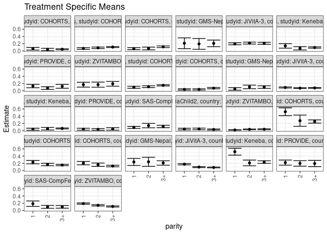

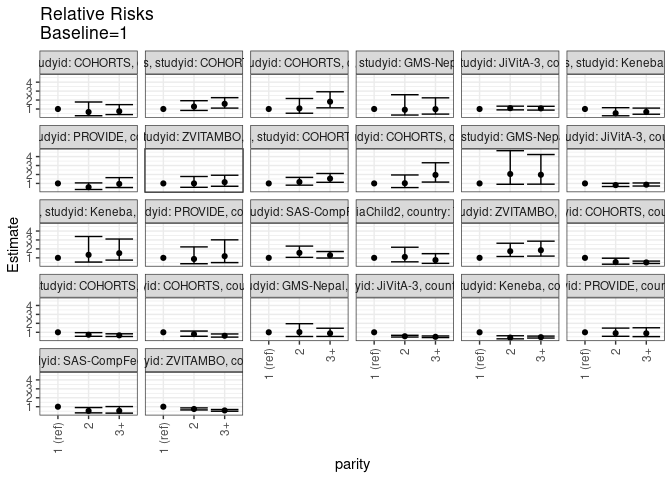

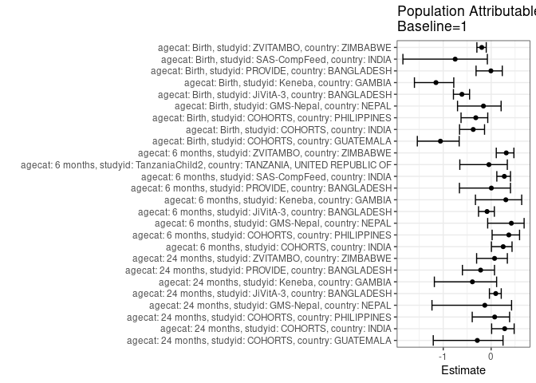

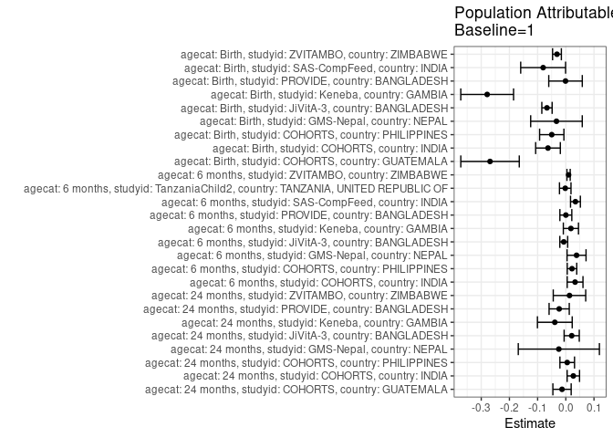

## Results Table

### Parameter: TSM

| agecat | studyid | country | intervention_level | baseline_level | estimate | ci_lower | ci_upper |
| --- | --- | --- | --- | --- | --- | --- | --- |
| Birth | COHORTS | GUATEMALA | 1 | NA | 0.5227657 | 0.4157625 | 0.6297688 |
| Birth | COHORTS | GUATEMALA | 2 | NA | 0.2764171 | 0.1212352 | 0.4315989 |
| Birth | COHORTS | GUATEMALA | 3+ | NA | 0.2539701 | 0.2096843 | 0.2982560 |
| Birth | COHORTS | INDIA | 1 | NA | 0.2320598 | 0.1861029 | 0.2780167 |
| Birth | COHORTS | INDIA | 2 | NA | 0.1686239 | 0.1351532 | 0.2020945 |
| Birth | COHORTS | INDIA | 3+ | NA | 0.1533968 | 0.1363390 | 0.1704546 |
| Birth | COHORTS | PHILIPPINES | 1 | NA | 0.2054260 | 0.1596238 | 0.2512281 |
| Birth | COHORTS | PHILIPPINES | 2 | NA | 0.1628590 | 0.1169206 | 0.2087974 |
| Birth | COHORTS | PHILIPPINES | 3+ | NA | 0.1260218 | 0.1047061 | 0.1473375 |
| Birth | GMS-Nepal | NEPAL | 1 | NA | 0.2390512 | 0.1412787 | 0.3368237 |
| Birth | GMS-Nepal | NEPAL | 2 | NA | 0.2431034 | 0.1182967 | 0.3679102 |
| Birth | GMS-Nepal | NEPAL | 3+ | NA | 0.2109254 | 0.1504608 | 0.2713901 |
| Birth | JiVitA-3 | BANGLADESH | 1 | NA | 0.1763301 | 0.1571506 | 0.1955096 |
| Birth | JiVitA-3 | BANGLADESH | 2 | NA | 0.0979824 | 0.0838675 | 0.1120974 |
| Birth | JiVitA-3 | BANGLADESH | 3+ | NA | 0.0868724 | 0.0750407 | 0.0987041 |
| Birth | Keneba | GAMBIA | 1 | NA | 0.5211163 | 0.4261337 | 0.6160989 |
| Birth | Keneba | GAMBIA | 2 | NA | 0.2114585 | 0.1332691 | 0.2896479 |
| Birth | Keneba | GAMBIA | 3+ | NA | 0.2350612 | 0.1986656 | 0.2714569 |
| Birth | PROVIDE | BANGLADESH | 1 | NA | 0.2209306 | 0.1515877 | 0.2902736 |
| Birth | PROVIDE | BANGLADESH | 2 | NA | 0.1983709 | 0.1232749 | 0.2734669 |
| Birth | PROVIDE | BANGLADESH | 3+ | NA | 0.1951762 | 0.1104585 | 0.2798940 |
| Birth | SAS-CompFeed | INDIA | 1 | NA | 0.1873398 | 0.1132187 | 0.2614610 |
| Birth | SAS-CompFeed | INDIA | 2 | NA | 0.0999430 | 0.0595513 | 0.1403347 |
| Birth | SAS-CompFeed | INDIA | 3+ | NA | 0.1005863 | 0.0634188 | 0.1377537 |
| Birth | ZVITAMBO | ZIMBABWE | 1 | NA | 0.1908643 | 0.1738471 | 0.2078815 |
| Birth | ZVITAMBO | ZIMBABWE | 2 | NA | 0.1421979 | 0.1250093 | 0.1593864 |
| Birth | ZVITAMBO | ZIMBABWE | 3+ | NA | 0.1115309 | 0.0966108 | 0.1264510 |
| 6 months | COHORTS | INDIA | 1 | NA | 0.0982024 | 0.0693443 | 0.1270605 |
| 6 months | COHORTS | INDIA | 2 | NA | 0.1140375 | 0.0892628 | 0.1388122 |
| 6 months | COHORTS | INDIA | 3+ | NA | 0.1512317 | 0.1340101 | 0.1684533 |
| 6 months | COHORTS | PHILIPPINES | 1 | NA | 0.0375557 | 0.0200944 | 0.0550169 |
| 6 months | COHORTS | PHILIPPINES | 2 | NA | 0.0384431 | 0.0214131 | 0.0554732 |
| 6 months | COHORTS | PHILIPPINES | 3+ | NA | 0.0733329 | 0.0549701 | 0.0916958 |
| 6 months | GMS-Nepal | NEPAL | 1 | NA | 0.0522876 | 0.0169835 | 0.0875917 |
| 6 months | GMS-Nepal | NEPAL | 2 | NA | 0.1073826 | 0.0576272 | 0.1571379 |
| 6 months | GMS-Nepal | NEPAL | 3+ | NA | 0.1030534 | 0.0662068 | 0.1399000 |
| 6 months | JiVitA-3 | BANGLADESH | 1 | NA | 0.0919226 | 0.0770450 | 0.1068003 |
| 6 months | JiVitA-3 | BANGLADESH | 2 | NA | 0.0748065 | 0.0641935 | 0.0854195 |
| 6 months | JiVitA-3 | BANGLADESH | 3+ | NA | 0.0792840 | 0.0694023 | 0.0891657 |
| 6 months | Keneba | GAMBIA | 1 | NA | 0.0410256 | 0.0131775 | 0.0688738 |
| 6 months | Keneba | GAMBIA | 2 | NA | 0.0548780 | 0.0200120 | 0.0897441 |
| 6 months | Keneba | GAMBIA | 3+ | NA | 0.0625000 | 0.0491515 | 0.0758485 |
| 6 months | PROVIDE | BANGLADESH | 1 | NA | 0.0412844 | 0.0148531 | 0.0677157 |
| 6 months | PROVIDE | BANGLADESH | 2 | NA | 0.0360360 | 0.0114985 | 0.0605736 |
| 6 months | PROVIDE | BANGLADESH | 3+ | NA | 0.0490798 | 0.0158874 | 0.0822721 |
| 6 months | SAS-CompFeed | INDIA | 1 | NA | 0.0902045 | 0.0621227 | 0.1182863 |
| 6 months | SAS-CompFeed | INDIA | 2 | NA | 0.1406838 | 0.0791079 | 0.2022596 |
| 6 months | SAS-CompFeed | INDIA | 3+ | NA | 0.1166966 | 0.0831877 | 0.1502055 |
| 6 months | TanzaniaChild2 | TANZANIA, UNITED REPUBLIC OF | 1 | NA | 0.0446193 | 0.0222020 | 0.0670367 |
| 6 months | TanzaniaChild2 | TANZANIA, UNITED REPUBLIC OF | 2 | NA | 0.0492244 | 0.0263865 | 0.0720623 |
| 6 months | TanzaniaChild2 | TANZANIA, UNITED REPUBLIC OF | 3+ | NA | 0.0335229 | 0.0186174 | 0.0484285 |
| 6 months | ZVITAMBO | ZIMBABWE | 1 | NA | 0.0213366 | 0.0151289 | 0.0275443 |
| 6 months | ZVITAMBO | ZIMBABWE | 2 | NA | 0.0371635 | 0.0261855 | 0.0481414 |
| 6 months | ZVITAMBO | ZIMBABWE | 3+ | NA | 0.0395300 | 0.0266878 | 0.0523722 |
| 24 months | COHORTS | GUATEMALA | 1 | NA | 0.0598802 | 0.0238784 | 0.0958821 |
| 24 months | COHORTS | GUATEMALA | 2 | NA | 0.0397351 | 0.0085646 | 0.0709056 |
| 24 months | COHORTS | GUATEMALA | 3+ | NA | 0.0448549 | 0.0301129 | 0.0595968 |
| 24 months | COHORTS | INDIA | 1 | NA | 0.0677797 | 0.0448046 | 0.0907548 |
| 24 months | COHORTS | INDIA | 2 | NA | 0.0862617 | 0.0654410 | 0.1070824 |
| 24 months | COHORTS | INDIA | 3+ | NA | 0.1069405 | 0.0932400 | 0.1206411 |
| 24 months | COHORTS | PHILIPPINES | 1 | NA | 0.0631554 | 0.0358443 | 0.0904665 |
| 24 months | COHORTS | PHILIPPINES | 2 | NA | 0.0674711 | 0.0293658 | 0.1055765 |
| 24 months | COHORTS | PHILIPPINES | 3+ | NA | 0.1147829 | 0.0920649 | 0.1375009 |
| 24 months | GMS-Nepal | NEPAL | 1 | NA | 0.2115596 | 0.0628501 | 0.3602690 |
| 24 months | GMS-Nepal | NEPAL | 2 | NA | 0.1938823 | 0.0453862 | 0.3423785 |
| 24 months | GMS-Nepal | NEPAL | 3+ | NA | 0.2081021 | 0.1179570 | 0.2982472 |
| 24 months | JiVitA-3 | BANGLADESH | 1 | NA | 0.1974022 | 0.1689994 | 0.2258049 |
| 24 months | JiVitA-3 | BANGLADESH | 2 | NA | 0.2153975 | 0.1886807 | 0.2421142 |
| 24 months | JiVitA-3 | BANGLADESH | 3+ | NA | 0.2107374 | 0.1821127 | 0.2393620 |
| 24 months | Keneba | GAMBIA | 1 | NA | 0.1385191 | 0.0763558 | 0.2006823 |
| 24 months | Keneba | GAMBIA | 2 | NA | 0.0728897 | 0.0267612 | 0.1190181 |
| 24 months | Keneba | GAMBIA | 3+ | NA | 0.0935387 | 0.0759795 | 0.1110979 |
| 24 months | PROVIDE | BANGLADESH | 1 | NA | 0.1305933 | 0.0841136 | 0.1770730 |
| 24 months | PROVIDE | BANGLADESH | 2 | NA | 0.0757952 | 0.0392649 | 0.1123254 |
| 24 months | PROVIDE | BANGLADESH | 3+ | NA | 0.1231218 | 0.0703021 | 0.1759415 |
| 24 months | ZVITAMBO | ZIMBABWE | 1 | NA | 0.1698160 | 0.1025994 | 0.2370326 |
| 24 months | ZVITAMBO | ZIMBABWE | 2 | NA | 0.1704835 | 0.1003605 | 0.2406064 |
| 24 months | ZVITAMBO | ZIMBABWE | 3+ | NA | 0.1939999 | 0.1291936 | 0.2588062 |

### Parameter: E(Y)

| agecat | studyid | country | intervention_level | baseline_level | estimate | ci_lower | ci_upper |
| --- | --- | --- | --- | --- | --- | --- | --- |
| Birth | COHORTS | GUATEMALA | NA | NA | 0.2539683 | 0.2229196 | 0.2850169 |
| Birth | COHORTS | INDIA | NA | NA | 0.1688716 | 0.1570438 | 0.1806994 |
| Birth | COHORTS | PHILIPPINES | NA | NA | 0.1555709 | 0.1423748 | 0.1687670 |
| Birth | GMS-Nepal | NEPAL | NA | NA | 0.2059282 | 0.1745993 | 0.2372572 |
| Birth | JiVitA-3 | BANGLADESH | NA | NA | 0.1095259 | 0.1044047 | 0.1146471 |
| Birth | Keneba | GAMBIA | NA | NA | 0.2421525 | 0.2191900 | 0.2651149 |
| Birth | PROVIDE | BANGLADESH | NA | NA | 0.2199248 | 0.1846953 | 0.2551543 |
| Birth | SAS-CompFeed | INDIA | NA | NA | 0.1069810 | 0.0760961 | 0.1378659 |
| Birth | ZVITAMBO | ZIMBABWE | NA | NA | 0.1595695 | 0.1532538 | 0.1658853 |
| 6 months | COHORTS | INDIA | NA | NA | 0.1311552 | 0.1210467 | 0.1412637 |
| 6 months | COHORTS | PHILIPPINES | NA | NA | 0.0594974 | 0.0505830 | 0.0684118 |
| 6 months | GMS-Nepal | NEPAL | NA | NA | 0.0904255 | 0.0667359 | 0.1141152 |
| 6 months | JiVitA-3 | BANGLADESH | NA | NA | 0.0846640 | 0.0798626 | 0.0894653 |
| 6 months | Keneba | GAMBIA | NA | NA | 0.0591497 | 0.0476693 | 0.0706302 |
| 6 months | PROVIDE | BANGLADESH | NA | NA | 0.0414594 | 0.0255348 | 0.0573839 |
| 6 months | SAS-CompFeed | INDIA | NA | NA | 0.1244378 | 0.0992652 | 0.1496104 |
| 6 months | TanzaniaChild2 | TANZANIA, UNITED REPUBLIC OF | NA | NA | 0.0426279 | 0.0337587 | 0.0514970 |
| 6 months | ZVITAMBO | ZIMBABWE | NA | NA | 0.0311618 | 0.0274686 | 0.0348550 |
| 24 months | COHORTS | GUATEMALA | NA | NA | 0.0464684 | 0.0338852 | 0.0590516 |
| 24 months | COHORTS | INDIA | NA | NA | 0.0945140 | 0.0846121 | 0.1044160 |
| 24 months | COHORTS | PHILIPPINES | NA | NA | 0.0681911 | 0.0582056 | 0.0781766 |
| 24 months | GMS-Nepal | NEPAL | NA | NA | 0.1868583 | 0.1522030 | 0.2215136 |
| 24 months | JiVitA-3 | BANGLADESH | NA | NA | 0.2182959 | 0.2084450 | 0.2281469 |
| 24 months | Keneba | GAMBIA | NA | NA | 0.0995640 | 0.0837378 | 0.1153901 |
| 24 months | PROVIDE | BANGLADESH | NA | NA | 0.1070812 | 0.0818727 | 0.1322897 |
| 24 months | ZVITAMBO | ZIMBABWE | NA | NA | 0.1828704 | 0.1463759 | 0.2193648 |

### Parameter: RR

| agecat | studyid | country | intervention_level | baseline_level | estimate | ci_lower | ci_upper |
| --- | --- | --- | --- | --- | --- | --- | --- |
| Birth | COHORTS | GUATEMALA | 1 | 1 | 1.0000000 | 1.0000000 | 1.0000000 |
| Birth | COHORTS | GUATEMALA | 2 | 1 | 0.5287590 | 0.2910754 | 0.9605279 |
| Birth | COHORTS | GUATEMALA | 3+ | 1 | 0.4858202 | 0.3713392 | 0.6355948 |
| Birth | COHORTS | INDIA | 1 | 1 | 1.0000000 | 1.0000000 | 1.0000000 |
| Birth | COHORTS | INDIA | 2 | 1 | 0.7266397 | 0.5489680 | 0.9618143 |
| Birth | COHORTS | INDIA | 3+ | 1 | 0.6610226 | 0.5267325 | 0.8295498 |
| Birth | COHORTS | PHILIPPINES | 1 | 1 | 1.0000000 | 1.0000000 | 1.0000000 |
| Birth | COHORTS | PHILIPPINES | 2 | 1 | 0.7927867 | 0.5533436 | 1.1358419 |
| Birth | COHORTS | PHILIPPINES | 3+ | 1 | 0.6134658 | 0.4637210 | 0.8115662 |
| Birth | GMS-Nepal | NEPAL | 1 | 1 | 1.0000000 | 1.0000000 | 1.0000000 |
| Birth | GMS-Nepal | NEPAL | 2 | 1 | 1.0169513 | 0.5275927 | 1.9602054 |
| Birth | GMS-Nepal | NEPAL | 3+ | 1 | 0.8823441 | 0.5355750 | 1.4536363 |
| Birth | JiVitA-3 | BANGLADESH | 1 | 1 | 1.0000000 | 1.0000000 | 1.0000000 |
| Birth | JiVitA-3 | BANGLADESH | 2 | 1 | 0.5556761 | 0.4671475 | 0.6609817 |
| Birth | JiVitA-3 | BANGLADESH | 3+ | 1 | 0.4926692 | 0.4131172 | 0.5875401 |
| Birth | Keneba | GAMBIA | 1 | 1 | 1.0000000 | 1.0000000 | 1.0000000 |
| Birth | Keneba | GAMBIA | 2 | 1 | 0.4057798 | 0.2687363 | 0.6127094 |
| Birth | Keneba | GAMBIA | 3+ | 1 | 0.4510725 | 0.3550484 | 0.5730666 |
| Birth | PROVIDE | BANGLADESH | 1 | 1 | 1.0000000 | 1.0000000 | 1.0000000 |
| Birth | PROVIDE | BANGLADESH | 2 | 1 | 0.8978878 | 0.5490547 | 1.4683466 |
| Birth | PROVIDE | BANGLADESH | 3+ | 1 | 0.8834276 | 0.5181600 | 1.5061841 |
| Birth | SAS-CompFeed | INDIA | 1 | 1 | 1.0000000 | 1.0000000 | 1.0000000 |
| Birth | SAS-CompFeed | INDIA | 2 | 1 | 0.5334851 | 0.3129944 | 0.9093016 |
| Birth | SAS-CompFeed | INDIA | 3+ | 1 | 0.5369188 | 0.2829363 | 1.0188928 |
| Birth | ZVITAMBO | ZIMBABWE | 1 | 1 | 1.0000000 | 1.0000000 | 1.0000000 |
| Birth | ZVITAMBO | ZIMBABWE | 2 | 1 | 0.7450206 | 0.6411234 | 0.8657549 |
| Birth | ZVITAMBO | ZIMBABWE | 3+ | 1 | 0.5843464 | 0.4975610 | 0.6862691 |
| 6 months | COHORTS | INDIA | 1 | 1 | 1.0000000 | 1.0000000 | 1.0000000 |
| 6 months | COHORTS | INDIA | 2 | 1 | 1.1612495 | 0.8057971 | 1.6734985 |
| 6 months | COHORTS | INDIA | 3+ | 1 | 1.5400000 | 1.1237219 | 2.1104866 |
| 6 months | COHORTS | PHILIPPINES | 1 | 1 | 1.0000000 | 1.0000000 | 1.0000000 |
| 6 months | COHORTS | PHILIPPINES | 2 | 1 | 1.0236310 | 0.5387785 | 1.9448075 |
| 6 months | COHORTS | PHILIPPINES | 3+ | 1 | 1.9526465 | 1.1515166 | 3.3111363 |
| 6 months | GMS-Nepal | NEPAL | 1 | 1 | 1.0000000 | 1.0000000 | 1.0000000 |
| 6 months | GMS-Nepal | NEPAL | 2 | 1 | 2.0536913 | 0.9055194 | 4.6577114 |
| 6 months | GMS-Nepal | NEPAL | 3+ | 1 | 1.9708969 | 0.9180260 | 4.2312905 |
| 6 months | JiVitA-3 | BANGLADESH | 1 | 1 | 1.0000000 | 1.0000000 | 1.0000000 |
| 6 months | JiVitA-3 | BANGLADESH | 2 | 1 | 0.8137987 | 0.6553890 | 1.0104965 |
| 6 months | JiVitA-3 | BANGLADESH | 3+ | 1 | 0.8625079 | 0.7082899 | 1.0503042 |
| 6 months | Keneba | GAMBIA | 1 | 1 | 1.0000000 | 1.0000000 | 1.0000000 |
| 6 months | Keneba | GAMBIA | 2 | 1 | 1.3376524 | 0.5279119 | 3.3894182 |
| 6 months | Keneba | GAMBIA | 3+ | 1 | 1.5234375 | 0.7477881 | 3.1036355 |
| 6 months | PROVIDE | BANGLADESH | 1 | 1 | 1.0000000 | 1.0000000 | 1.0000000 |
| 6 months | PROVIDE | BANGLADESH | 2 | 1 | 0.8728729 | 0.3428041 | 2.2225725 |
| 6 months | PROVIDE | BANGLADESH | 3+ | 1 | 1.1888207 | 0.4684591 | 3.0169011 |
| 6 months | SAS-CompFeed | INDIA | 1 | 1 | 1.0000000 | 1.0000000 | 1.0000000 |
| 6 months | SAS-CompFeed | INDIA | 2 | 1 | 1.5596089 | 1.0521271 | 2.3118689 |
| 6 months | SAS-CompFeed | INDIA | 3+ | 1 | 1.2936894 | 0.9802265 | 1.7073933 |
| 6 months | TanzaniaChild2 | TANZANIA, UNITED REPUBLIC OF | 1 | 1 | 1.0000000 | 1.0000000 | 1.0000000 |
| 6 months | TanzaniaChild2 | TANZANIA, UNITED REPUBLIC OF | 2 | 1 | 1.1032078 | 0.5569201 | 2.1853537 |
| 6 months | TanzaniaChild2 | TANZANIA, UNITED REPUBLIC OF | 3+ | 1 | 0.7513097 | 0.3841025 | 1.4695717 |
| 6 months | ZVITAMBO | ZIMBABWE | 1 | 1 | 1.0000000 | 1.0000000 | 1.0000000 |
| 6 months | ZVITAMBO | ZIMBABWE | 2 | 1 | 1.7417696 | 1.1506784 | 2.6364981 |
| 6 months | ZVITAMBO | ZIMBABWE | 3+ | 1 | 1.8526843 | 1.1978041 | 2.8656098 |
| 24 months | COHORTS | GUATEMALA | 1 | 1 | 1.0000000 | 1.0000000 | 1.0000000 |
| 24 months | COHORTS | GUATEMALA | 2 | 1 | 0.6635762 | 0.2469743 | 1.7829113 |
| 24 months | COHORTS | GUATEMALA | 3+ | 1 | 0.7490765 | 0.3775276 | 1.4862905 |
| 24 months | COHORTS | INDIA | 1 | 1 | 1.0000000 | 1.0000000 | 1.0000000 |
| 24 months | COHORTS | INDIA | 2 | 1 | 1.2726776 | 0.8402291 | 1.9276984 |
| 24 months | COHORTS | INDIA | 3+ | 1 | 1.5777664 | 1.0987585 | 2.2655997 |
| 24 months | COHORTS | PHILIPPINES | 1 | 1 | 1.0000000 | 1.0000000 | 1.0000000 |
| 24 months | COHORTS | PHILIPPINES | 2 | 1 | 1.0683348 | 0.5246838 | 2.1752899 |
| 24 months | COHORTS | PHILIPPINES | 3+ | 1 | 1.8174677 | 1.1296510 | 2.9240792 |
| 24 months | GMS-Nepal | NEPAL | 1 | 1 | 1.0000000 | 1.0000000 | 1.0000000 |
| 24 months | GMS-Nepal | NEPAL | 2 | 1 | 0.9164433 | 0.3237067 | 2.5945346 |
| 24 months | GMS-Nepal | NEPAL | 3+ | 1 | 0.9836571 | 0.4307542 | 2.2462490 |
| 24 months | JiVitA-3 | BANGLADESH | 1 | 1 | 1.0000000 | 1.0000000 | 1.0000000 |
| 24 months | JiVitA-3 | BANGLADESH | 2 | 1 | 1.0911607 | 0.9032728 | 1.3181308 |
| 24 months | JiVitA-3 | BANGLADESH | 3+ | 1 | 1.0675535 | 0.8751465 | 1.3022625 |
| 24 months | Keneba | GAMBIA | 1 | 1 | 1.0000000 | 1.0000000 | 1.0000000 |
| 24 months | Keneba | GAMBIA | 2 | 1 | 0.5262065 | 0.2421829 | 1.1433232 |
| 24 months | Keneba | GAMBIA | 3+ | 1 | 0.6752765 | 0.4153264 | 1.0979277 |
| 24 months | PROVIDE | BANGLADESH | 1 | 1 | 1.0000000 | 1.0000000 | 1.0000000 |
| 24 months | PROVIDE | BANGLADESH | 2 | 1 | 0.5803910 | 0.3184426 | 1.0578161 |
| 24 months | PROVIDE | BANGLADESH | 3+ | 1 | 0.9427878 | 0.5398773 | 1.6463905 |
| 24 months | ZVITAMBO | ZIMBABWE | 1 | 1 | 1.0000000 | 1.0000000 | 1.0000000 |
| 24 months | ZVITAMBO | ZIMBABWE | 2 | 1 | 1.0039305 | 0.5675779 | 1.7757502 |
| 24 months | ZVITAMBO | ZIMBABWE | 3+ | 1 | 1.1424123 | 0.6811465 | 1.9160428 |

### Parameter: PAR

| agecat | studyid | country | intervention_level | baseline_level | estimate | ci_lower | ci_upper |
| --- | --- | --- | --- | --- | --- | --- | --- |
| Birth | COHORTS | GUATEMALA | 1 | NA | -0.2687974 | -0.3725250 | -0.1650699 |
| Birth | COHORTS | INDIA | 1 | NA | -0.0631882 | -0.1069749 | -0.0194015 |
| Birth | COHORTS | PHILIPPINES | 1 | NA | -0.0498551 | -0.0929523 | -0.0067579 |
| Birth | GMS-Nepal | NEPAL | 1 | NA | -0.0331230 | -0.1246058 | 0.0583599 |
| Birth | JiVitA-3 | BANGLADESH | 1 | NA | -0.0668042 | -0.0850743 | -0.0485340 |
| Birth | Keneba | GAMBIA | 1 | NA | -0.2789638 | -0.3725843 | -0.1853433 |
| Birth | PROVIDE | BANGLADESH | 1 | NA | -0.0010058 | -0.0604657 | 0.0584540 |
| Birth | SAS-CompFeed | INDIA | 1 | NA | -0.0803588 | -0.1599846 | -0.0007331 |
| Birth | ZVITAMBO | ZIMBABWE | 1 | NA | -0.0312948 | -0.0468693 | -0.0157203 |
| 6 months | COHORTS | INDIA | 1 | NA | 0.0329528 | 0.0049859 | 0.0609196 |
| 6 months | COHORTS | PHILIPPINES | 1 | NA | 0.0219417 | 0.0051327 | 0.0387508 |
| 6 months | GMS-Nepal | NEPAL | 1 | NA | 0.0381380 | 0.0045024 | 0.0717735 |
| 6 months | JiVitA-3 | BANGLADESH | 1 | NA | -0.0072587 | -0.0211856 | 0.0066682 |
| 6 months | Keneba | GAMBIA | 1 | NA | 0.0181241 | -0.0087267 | 0.0449749 |
| 6 months | PROVIDE | BANGLADESH | 1 | NA | 0.0001750 | -0.0209691 | 0.0213190 |
| 6 months | SAS-CompFeed | INDIA | 1 | NA | 0.0342333 | 0.0167809 | 0.0516856 |
| 6 months | TanzaniaChild2 | TANZANIA, UNITED REPUBLIC OF | 1 | NA | -0.0019915 | -0.0224112 | 0.0184283 |
| 6 months | ZVITAMBO | ZIMBABWE | 1 | NA | 0.0098252 | 0.0040428 | 0.0156076 |
| 24 months | COHORTS | GUATEMALA | 1 | NA | -0.0134118 | -0.0458485 | 0.0190249 |
| 24 months | COHORTS | INDIA | 1 | NA | 0.0267343 | 0.0047312 | 0.0487374 |
| 24 months | COHORTS | PHILIPPINES | 1 | NA | 0.0050357 | -0.0208511 | 0.0309225 |
| 24 months | GMS-Nepal | NEPAL | 1 | NA | -0.0247012 | -0.1686121 | 0.1192096 |
| 24 months | JiVitA-3 | BANGLADESH | 1 | NA | 0.0208938 | -0.0059781 | 0.0477657 |
| 24 months | Keneba | GAMBIA | 1 | NA | -0.0389551 | -0.1006169 | 0.0227066 |
| 24 months | PROVIDE | BANGLADESH | 1 | NA | -0.0235121 | -0.0592735 | 0.0122492 |
| 24 months | ZVITAMBO | ZIMBABWE | 1 | NA | 0.0130544 | -0.0445233 | 0.0706321 |

### Parameter: PAF

| agecat | studyid | country | intervention_level | baseline_level | estimate | ci_lower | ci_upper |
| --- | --- | --- | --- | --- | --- | --- | --- |
| Birth | COHORTS | GUATEMALA | 1 | NA | -1.0583899 | -1.5410960 | -0.6673786 |
| Birth | COHORTS | INDIA | 1 | NA | -0.3741791 | -0.6594681 | -0.1379357 |
| Birth | COHORTS | PHILIPPINES | 1 | NA | -0.3204654 | -0.6283835 | -0.0707728 |
| Birth | GMS-Nepal | NEPAL | 1 | NA | -0.1608471 | -0.7017448 | 0.2081269 |
| Birth | JiVitA-3 | BANGLADESH | 1 | NA | -0.6099395 | -0.7870754 | -0.4503613 |
| Birth | Keneba | GAMBIA | 1 | NA | -1.1520173 | -1.6016360 | -0.7801023 |
| Birth | PROVIDE | BANGLADESH | 1 | NA | -0.0045735 | -0.3148098 | 0.2324610 |
| Birth | SAS-CompFeed | INDIA | 1 | NA | -0.7511509 | -1.8421002 | -0.0789660 |
| Birth | ZVITAMBO | ZIMBABWE | 1 | NA | -0.1961201 | -0.2978460 | -0.1023675 |
| 6 months | COHORTS | INDIA | 1 | NA | 0.2512503 | 0.0057317 | 0.4361420 |
| 6 months | COHORTS | PHILIPPINES | 1 | NA | 0.3687849 | 0.0205172 | 0.5932216 |
| 6 months | GMS-Nepal | NEPAL | 1 | NA | 0.4217609 | -0.0723843 | 0.6882083 |
| 6 months | JiVitA-3 | BANGLADESH | 1 | NA | -0.0857352 | -0.2632470 | 0.0668326 |
| 6 months | Keneba | GAMBIA | 1 | NA | 0.3064103 | -0.3277240 | 0.6376757 |
| 6 months | PROVIDE | BANGLADESH | 1 | NA | 0.0042202 | -0.6618377 | 0.4033247 |
| 6 months | SAS-CompFeed | INDIA | 1 | NA | 0.2751035 | 0.1184801 | 0.4038990 |
| 6 months | TanzaniaChild2 | TANZANIA, UNITED REPUBLIC OF | 1 | NA | -0.0467172 | -0.6540374 | 0.3376106 |
| 6 months | ZVITAMBO | ZIMBABWE | 1 | NA | 0.3152962 | 0.1070586 | 0.4749719 |
| 24 months | COHORTS | GUATEMALA | 1 | NA | -0.2886228 | -1.2084474 | 0.2480923 |
| 24 months | COHORTS | INDIA | 1 | NA | 0.2828608 | 0.0103371 | 0.4803395 |
| 24 months | COHORTS | PHILIPPINES | 1 | NA | 0.0738469 | -0.3948686 | 0.3850606 |
| 24 months | GMS-Nepal | NEPAL | 1 | NA | -0.1321924 | -1.2351256 | 0.4264933 |
| 24 months | JiVitA-3 | BANGLADESH | 1 | NA | 0.0957131 | -0.0361281 | 0.2107782 |
| 24 months | Keneba | GAMBIA | 1 | NA | -0.3912575 | -1.1855524 | 0.1143670 |
| 24 months | PROVIDE | BANGLADESH | 1 | NA | -0.2195729 | -0.5997113 | 0.0702335 |
| 24 months | ZVITAMBO | ZIMBABWE | 1 | NA | 0.0713859 | -0.3032662 | 0.3383361 |